0

# Corrigé du livret stagiaire · mode d'emploi

Document formateur · ne pas distribuer

**Deux sortes de réponses.** Les questions de raisonnement ont une réponse fixe, donnée ici. Les nombres des fiches B, C, D et I dépendent des mesures faites le jour même (échantillons 7 à 10, séries Cg). Pour ces fiches, le corrigé donne les valeurs calculées sur les **30 valeurs du fichier** (échantillons 1 à 6) : elles servent à vérifier les formules des stagiaires **avant** la saisie des mesures. Après la saisie, le classeur `Corriges_formateur/Corrige_TP_Butees.xlsx` donne les vraies valeurs.

Chaque réponse renvoie à sa source : [Livret p. page, fiche, question]. Les pages sont celles du PDF `Livret_Stagiaire_TQ6_v3.pdf` (19 pages).

## Mots à connaître [Livret p. 1, fiche couverture, tableau « Mots à connaître »]

[output not shown]

## Fiche X · Excel [Livret p. 2, fiche X]

Pas de question. Points à contrôler sur chaque poste : fichier enregistré en **.xlsx** (sinon les formules disparaissent à la fermeture) ; nombres alignés à droite (un nombre aligné à gauche est du texte, souvent un point au lieu d'une virgule) ; `$` présents dans les références qui doivent rester fixes.

A·B

# Corrigé · fiches A et B

Flash mesure, le lot, l'histogramme

## Fiche A · flash mesure [Livret p. 3, fiche A]

**Q1. Quelle est la vraie valeur ?** On ne la connaît pas. Chaque lecture est la vraie valeur plus une erreur de mesure. On peut seulement estimer la vraie valeur (par exemple par la moyenne de mesures soignées) et chiffrer l'erreur : c'est l'objet de la fiche I.

**Q2. Trois causes des écarts.** Attendues, classées 5M : **Méthode** (endroit de mesure sur le téton, mesure près du chanfrein ou de l'épaulement, pièce de travers dans les becs) ; **Main-d'œuvre** (force de serrage sur le pied, lecture du vernier, parallaxe) ; **Moyen** (résolution 0,02 du pied, zéro mal fait, usure des becs) ; **Milieu** (température, main qui chauffe la pièce) ; **Matière** (bavure, ovalisation, saleté). Accepter toute cause justifiée.

**Q3. Quel instrument pour 11,85 / 12,00 ?** Le micromètre. IT = 0,15 mm : la règle du 1/10 demande une résolution d'au plus 0,015 mm. Le pied au 0,02 ne la respecte pas, le micromètre au 0,001 la respecte largement. Attendu au tableau : l'écart maxi entre stagiaires est nettement plus grand au pied qu'au micromètre.

## Fiche B · le lot [Livret p. 4, fiche B]

**Contrôles de la feuille avant saisie des mesures** (30 valeurs) : K4 = 30 ; K5 = 11,8867 ; K6 = 0,0264 ; K7 = 11,84 ; K8 = 11,93 ; K9 = 0,1586 ; L30 = 30. Moyennes G2:G7 : 11,864, 11,862, 11,884, 11,898, 11,910, 11,902 ; étendues H2:H7 : 0,04, 0,05, 0,05, 0,04, 0,04, 0,08. Après saisie : K4 = 50 et L30 = 50.

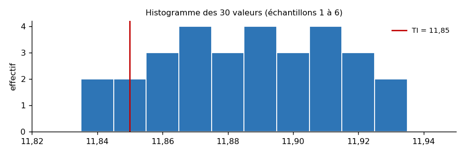

**Q1. Forme de l'histogramme.** Sur les 30 valeurs : une bosse unique, à peu près symétrique, de 11,84 à 11,93, centrée vers 11,89. Elle est collée à la limite basse 11,85 : deux valeurs à 11,84 sont hors tolérance. Avec les 50 valeurs, regarder si nos butées forment une seconde bosse (autre réglage, autre instrument).

**Q2. Pourquoi des bornes à 11,825 ; 11,835… ?** Pour qu'aucune mesure au 0,01 ne tombe pile sur une borne : chaque valeur est au milieu de sa classe. Les mesures au 0,001 qui tombent sur une borne (par exemple 11,835) vont dans la classe du dessus, grâce à « ≥ borne basse et < borne haute ».

**Q3. Mélange 0,01 et 0,001, gênant ?** Peu pour l'histogramme (classes de 0,01). Arrondir au 0,01 ajoute une variance de $0,012/12$, soit un écart-type de 0,003 mm, négligeable devant 0,026. Le vrai risque est ailleurs : instruments, opérateurs et lot différents entre les échantillons 1 à 6 et 7 à 10. On y revient fiche D, Q3.

H·C

# Corrigé · fiches H et C

Droite de Henry, capabilité, trois clients

## Fiche H · droite de Henry [Livret p. 5, fiche H]

Contrôles : B2 = 11,84 (plus petite valeur) ; C2 = (1 − 0,5)/30 ≈ 0,0167 ; D2 ≈ −2,13. Avec 50 valeurs, C2 = 0,01 et D2 ≈ −2,33.

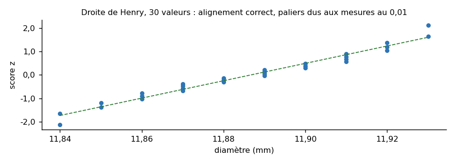

**Q1. Points alignés ?** Sur les 30 valeurs, oui dans l'ensemble : rien ne permet de rejeter la loi normale. Les écarts sont aux extrémités, là où il y a très peu de points.

**Q2. Les marches d'escalier ?** Les valeurs au 0,01 se répètent (quatre fois 11,87, quatre fois 11,91…) : plusieurs rangs pour une même mesure, d'où des paliers horizontaux. C'est la résolution, pas un défaut du procédé.

**Q3. 50 valeurs, assez ?** Assez pour voir un mélange ou un tri grossier, pas pour trancher sur une légère asymétrie. Pour être sûr : plus de données, ou un test chiffré (Shapiro-Wilk sous R ou Ellistat).

## Fiche C · capabilité [Livret p. 6, fiche C]

| X̿ (N2) | R̄ (N3) | σ inst. (N5) | s (K6) | Cp | Cpk | Pp | Ppk |
| --- | --- | --- | --- | --- | --- | --- | --- |
| 11,8867 | 0,050 | 0,0215 | 0,0264 | 1,16 | 0,57 | 0,95 | 0,46 |

Calcul de contrôle : $Cp=6×0,02150,15≈1,16Cpk=3×0,021511,8867−11,85≈0,57$

**Trois clients**, règle du guide appliquée aux 30 valeurs (m = 11,8867 ; s = 0,0264), à titre d'exemple :

|  | TI | TS | Cp | Cpk | Pp | Ppk | Verdict attendu |
| --- | --- | --- | --- | --- | --- | --- | --- |
| Client 1 (plan) | 11,85 | 12,00 | 1,16 | 0,57 | 0,95 | 0,46 | Non capable : décentré bas et un peu trop dispersé. Recentrer, puis réduire la dispersion. En attendant : trier. |
| Client 2 (serré) | 11,827 | 11,946 | 0,92 | 0,92 | 0,75 | 0,75 | Centré mais trop large : régler ne sert à rien, il faut réduire la dispersion (5M). Trier en attendant. |
| Client 3 (décentré) | 11,860 | 12,125 | 2,05 | 0,41 | 1,67 | 0,34 | Dispersion très bonne, mal centré : un simple réglage vers le milieu (11,99) suffit. |

**Q1. Pp nettement plus petit que Cp ?** Oui : 0,95 contre 1,16. Les moyennes d'échantillons montent de 11,862 à 11,910 : le réglage bouge d'un échantillon à l'autre. Cette dérive entre dans s, pas dans R̄.

**Q2. Dispersion ou réglage ?** Les deux. Le procédé vise 11,887 pour un milieu de tolérance à 11,925 : recentrer d'environ +0,04 mm ferait passer Cpk vers Cp. Mais Cp = 1,16 < 1,33 : même centré, il faut réduire la dispersion à court terme et stabiliser le réglage.

D

# Corrigé · fiche D

Carte X̄/R des butées, deux conventions

**Contrôles des colonnes P à Z** (30 valeurs, ligne 2, constantes sur toute la colonne) :

|  | LC (P) | LCS (Q) | LCI (R) | LSS (S) | LSI (T) | R̄ (W) | LC2 (X) | LS2 (Y) |
| --- | --- | --- | --- | --- | --- | --- | --- | --- |
| **AFNOR** | 11,8867 | 11,9164 | 11,8570 | 11,9055 | 11,8678 | 0,050 | 0,1180 | 0,0905 |
| **3 sigmas** | 11,8867 | U : 11,9155 | V : 11,8578 |  |  | 0,050 | Z : 0,1057 |  |

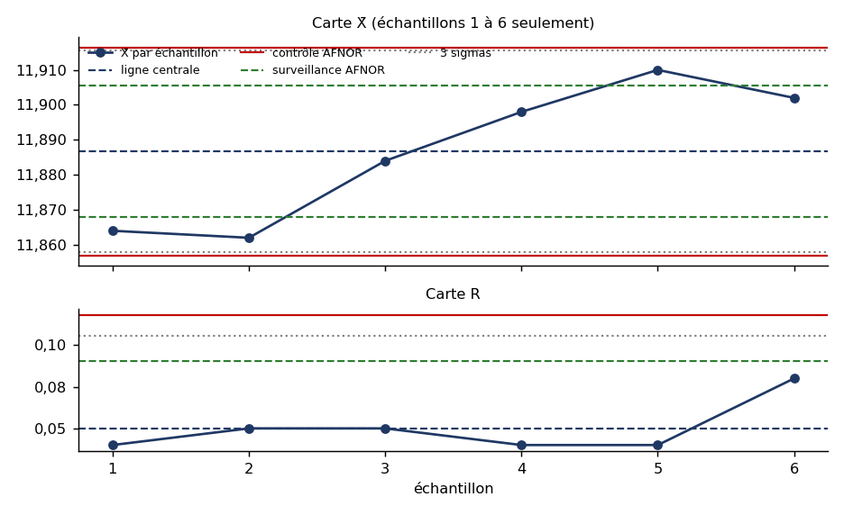

**Q1. Quelles limites sont les plus larges ? Ça change une décision ?** Les limites AFNOR de contrôle (3,09 σ contre 3 σ ; 2,36 R̄ contre 2,114 R̄), de très peu. Sur nos données, aucun point ne sort des limites de contrôle, ni d'un côté ni de l'autre. La différence de décision vient des **limites de surveillance**, que seule la carte AFNOR possède (Q2). [Livret p. 8, fiche D, Q1]

**Q2. Le procédé est-il sous contrôle ?** À 3 sigmas : oui, aucune règle déclenchée. En AFNOR : les échantillons 1 et 2 (11,864 et 11,862) sont dans la zone de surveillance basse, deux fois de suite : on aurait dû régler. L'échantillon 5 (11,910) est dans la zone haute. Carte R : rien. Avec les 50 valeurs, refaire la lecture : si nos butées sont toutes au-dessus de la ligne centrale, chercher la règle des 7 points. [Livret p. 8, fiche D, Q2]

**Q3. Les échantillons 7 à 10 peuvent-ils créer une fausse alarme ?** Oui. Entre l'échantillon 6 et le 7 changent l'instrument (pied ou micromètre inconnu contre micromètre au 0,001), les opérateurs (quatre personnes, quatre micromètres) et le lot de pièces. Un saut de moyenne peut venir de la mesure seule. C'est exactement la question de la fiche I. [Livret p. 8, fiche D, Q3]

**Q4. La carte explique-t-elle l'écart entre Cp et Pp ?** Oui : les moyennes bougent d'un échantillon à l'autre (montée de 11,862 à 11,910). R̄ ne voit pas ce déplacement, s le voit. [Livret p. 8, fiche D, Q4]

**Q5. Hors limites de contrôle et bonne ? L'inverse ?** Oui dans les deux sens. Une moyenne peut sortir des limites de contrôle avec des pièces toutes dans la tolérance (signal précoce d'une cause spéciale). Un procédé sous contrôle mais trop dispersé produit des pièces hors tolérance sans aucune alarme (client 2). Limites de contrôle et tolérances n'ont rien à voir. [Livret p. 8, fiche D, Q5]

E

# Corrigé · fiche E, enquêtes E1 et E2

Limites à 3 sigmas · Corrige_Exercices_SPC.xlsx, onglets E1 et E2

## E1 · pression [Livret p. 9, fiche E1]

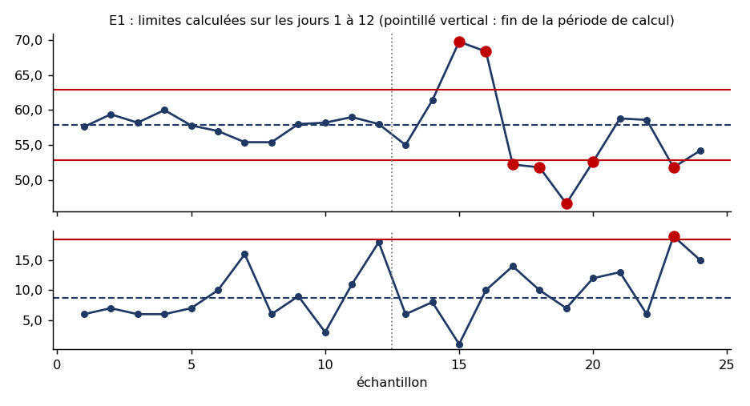

**a) Sans limites ?** On voit les jours 15 et 16 très hauts (69,8 et 68,4), les jours 17 à 20 et 23 bas (jusqu'à 46,6). Sans limites, on ne peut pas dire ce qui est normal : on discute des impressions.

**b) Limites sur les 12 premiers jours.** X̿ = 57,83 ; R̄ = 8,75 ; LCS = 62,88 ; LCI = 52,78 ; LCS(R) = 18,50. Hors limites X̄ : jours 15, 16, 17, 18, 19, 20, 23. Hors limites R : jour 23.

**c) Limites sur les 24 jours.** X̿ = 57,30 ; R̄ = 9,42 ; LCS = 62,73 ; LCI = 51,87 ; LCS(R) = 19,91. Hors limites X̄ : jours 15, 16, 18, 19, 23 (les jours 17, 20 disparaissent). Plus rien sur R. En AFNOR, seuls 15, 16, 19 sortiraient.

**d) Pourquoi les limites bougent ? La plus honnête ?** Les jours perturbés gonflent R̄ et déplacent X̿ : les limites s'élargissent et cachent une partie des problèmes. La carte (b), calculée sur une période stable, est la bonne pour surveiller. Règle : on calcule les limites sur une période sans cause spéciale, puis on les fige.

## E2 · liquide [Livret p. 9, fiche E2]

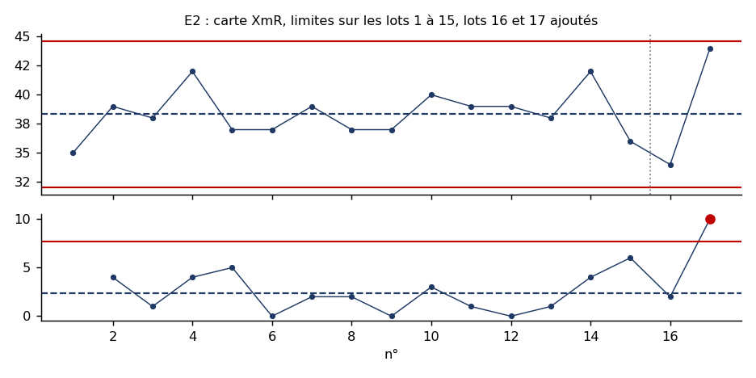

**a) Carte XmR sur 15 lots.** X̄ = 38,33 ; m̄R = 2,357 ; LCS = 44,60 ; LCI = 32,06 ; LCS(mR) = 7,70. Aucun point hors limites : procédé sous contrôle.

**b) Lots 16 (34) et 17 (44).** Lot 16 : dans les limites, mR = 2. Lot 17 : 44 reste sous 44,60, mais mR = 10 dépasse 7,70 : saut anormal entre deux lots, alarme sur la carte mR seulement. On lit toujours les deux cartes.

E

# Corrigé · fiche E, enquêtes E3 et E4

Limites à 3 sigmas · onglets E3 et E4

## E3 · billes [Livret p. 10, fiche E3]

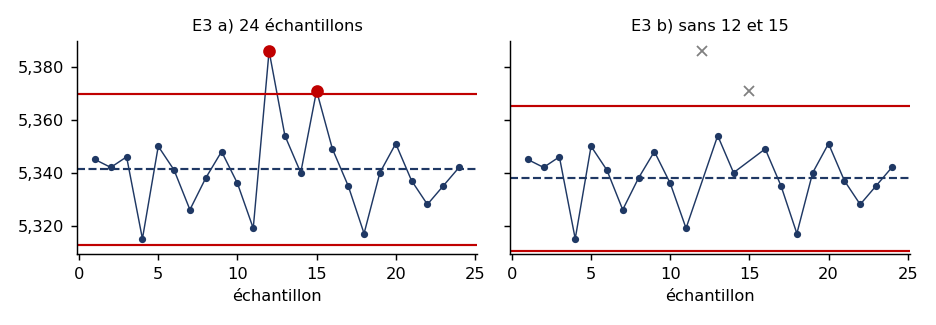

**a) 24 échantillons.** X̿ = 5,3413 ; R̄ = 0,0495 ; LCS = 5,3699 ; LCI = 5,3127 ; LCS(R) = 0,1046. Échantillons 12, 15 au-dessus de la LCS (5,386 et 5,371). Carte R en contrôle. Procédé hors contrôle statistique.

**b) Sans 12 et 15.** X̿ = 5,3379 ; R̄ = 0,0476 ; LCS = 5,3654 ; LCI = 5,3104 ; LCS(R) = 0,1006. Les 22 échantillons retenus sont tous dans les limites : on peut figer ces limites.

**c) Pourquoi une cause avant de retirer ?** Retirer un point sans cause, c'est maquiller les données : les limites deviennent trop étroites et la carte sonnera à tort. Un point sans cause trouvée reste dans le calcul.

## E4 · dimension [Livret p. 10, fiche E4]

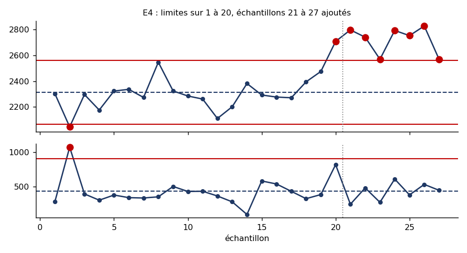

**a) Limites sur 1 à 20.** X̿ = 2314,1 ; R̄ = 429,4 ; LCS = 2561,9 ; LCI = 2066,4 ; LCS(R) = 907,8. Non : l'échantillon 2 sort en bas sur X̄ et en haut sur R (étendue 2 493 − 1 421 = 1 072). La valeur 1 421 est aberrante : erreur de saisie ou pièce défectueuse, à vérifier. L'échantillon 20 sort déjà en haut.

**b) Échantillons 21 à 27.** Tous au-dessus de la LCS : la moyenne du procédé a monté, à partir de l'échantillon 20. Cause spéciale certaine. La carte R reste en contrôle : c'est le réglage qui a bougé, pas la dispersion.

**c) Que faire, dans l'ordre ?** Arrêter et sécuriser les pièces produites depuis l'échantillon 20 ; chercher la cause (réglage, outil, matière, changement d'équipe) ; corriger ; vérifier sur de nouveaux échantillons ; tracer. Puis recalculer les limites sur 1 à 20 sans l'échantillon 2 si sa cause est trouvée.

Le fichier donne 2 681 pour la 3<sup>e</sup> pièce de l'échantillon 15, l'énoncé papier d'origine 2 651. Sans effet sur les conclusions.

E

# Corrigé · fiche E, enquête E5

Le sur-réglage chiffré · onglets E5_X_sans et E5_Y_avec

## E5 · intervention [Livret p. 11, fiche E5]

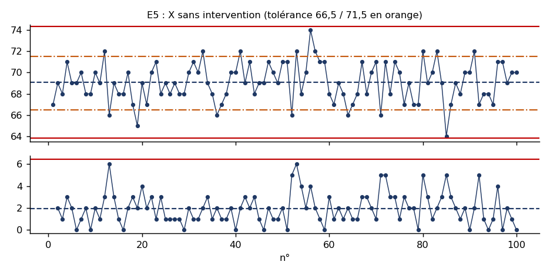

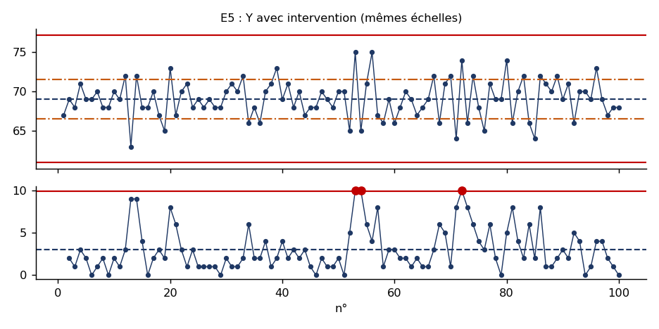

|  | Moyenne | m̄R | LCS | LCI | σ carte (m̄R / 1,128) | s | Hors tolérance | Alarmes |
| --- | --- | --- | --- | --- | --- | --- | --- | --- |
| **X sans** | 69,07 | 1,97 | 74,31 | 63,83 | 1,75 | 1,82 | 16 | aucune |
| **Y avec** | 69,05 | 3,04 | 77,14 | 60,96 | 2,70 | 2,43 | 32 | 3 sur mR (t = 53, 54, 72) |

**a) X stable ? Hors tolérance ?** Oui, stable : aucun point hors limites, aucune règle déclenchée. Mais pas capable : Pp = 0,46 ; 16 valeurs hors tolérance sur 100. Le procédé est stable et trop dispersé pour cette tolérance.

**b) Y comparé à X.** Limites plus larges (60,96 à 77,14 contre 63,83 à 74,31), deux fois plus de valeurs hors tolérance (32 contre 16), et trois alarmes sur la carte mR créées par les corrections elles-mêmes.

**c) Écart-type, l'intervention a-t-elle aidé ?** Non : s passe de 1,82 à 2,43. Corriger sur une valeur isolée, dans un procédé stable, ajoute de la dispersion.

**d) Lien avec Deming. Quand corriger ?** C'est l'entonnoir de Deming (TP08) : on déplace la cible à chaque bille, la dispersion augmente. On corrige quand la carte signale une cause spéciale, ou pour recentrer un décalage confirmé par plusieurs échantillons. Pour réduire les hors tolérance d'un procédé stable, il faut réduire sa dispersion propre, pas jouer du réglage.

## Mise en commun [Livret p. 11, fiche E, tableau final]

| Enquête | Verdict en une phrase | Ce qui le prouve |
| --- | --- | --- |
| E1 | Procédé perturbé du 21 décembre au 12 janvier. | Jours 15 à 20 et 23 hors limites (calcul sur 12 jours). |
| E2 | Saut anormal au lot 17. | mR = 10 > 7,70. |
| E3 | Deux échantillons anormaux, le reste stable. | 12 et 15 > LCS ; tout rentre après retrait. |
| E4 | Décalage du réglage à partir de l'échantillon 20. | 20 à 27 au-dessus de la LCS, R stable. |
| E5 | Corriger à chaque hors tolérance aggrave tout. | s de 1,82 à 2,43 ; 16 puis 32 hors tolérance. |

M·I

# Corrigé · fiches M et I

Mission d'intersession, capabilité de l'instrument

## Fiche M · mission [Livret p. 12, fiche M]

Pas de réponse unique. Points à faire ressortir pendant le retour de mission :

- Règle du 1/10 : la faire calculer en direct pour chaque cote présentée.
- Validation de l'instrument : distinguer étalonnage (justesse sur étalon, fait par le labo), étude Cg/Cgk (instrument au poste) et étude R&R (instrument, opérateurs et pièces).
- Surveillance : type de carte, taille et fréquence des prélèvements, convention AFNOR ou 3 sigmas. Souvent personne ne sait : c'est une découverte utile.
- Plan de réaction : existe-t-il, qui l'a écrit, est-il appliqué ? Le relier à la case 5 de l'affiche F.

## Fiche I · Cg et Cgk [Livret p. 13, fiche I, tableau « Avant de mesurer »]

| Instrument | Résolution | Résolution / T | Verdict a priori |
| --- | --- | --- | --- |
| Micromètre numérique | 0,001 mm | 0,7 % | Passe (sous 5 %) |
| Pied à coulisse 1/50 | 0,02 mm | 13 % | Échoue, même au seuil de 10 % |

**Les résultats chiffrés dépendent des mesures du jour** : `Corrige_Cg_Cgk.xlsx` les calcule dès la saisie de x_réf et des 3 séries. Repère : $Cg≥1,33⟺s≤6×1,330,2×0,15≈0,0038$ mm.

**Q1. Micromètre capable ? Pied ?** Micromètre : capable si Cg et Cgk ≥ 1,33, ce qui demande s ≤ 0,0038 mm et un biais petit. Pied à coulisse : non, la résolution l'élimine avant tout calcul. [Livret p. 14, fiche I, Q1]

**Q2. Valeurs différentes au pied ; s si tout est identique ?** On lit en général 1 à 3 valeurs différentes. Si les 25 lectures sont identiques, s = 0 et Cg est infini (division par zéro) : la résolution trop grossière cache la dispersion, l'instrument n'est pas parfait pour autant. Une seule lecture différente sur 25 donne s ≈ 0,004 mm : le verdict tient à un fil. On conclut sur la règle des 5 %. [Livret p. 14, fiche I, Q2]

**Q3. Séries 1 et 2, deux opérateurs.** Comparer |x̄₁ − x̄₂| à 0,1 T = 0,015 mm (repère pédagogique, pas un critère normalisé). Un écart de quelques millièmes et plus signale un effet opérateur : endroit de mesure, utilisation ou non du cliquet, pièce tenue de travers, main qui chauffe. C'est ce que mesure la reproductibilité d'une étude R&R. [Livret p. 14, fiche I, Q3]

**Q4. Que mesure vraiment le biais ?** x_réf a été mesurée par le formateur avec un seul micromètre (M1). Le biais trouvé est celui du micromètre du binôme par rapport à M1, pas par rapport à la vraie cote. Cgk est donc indicatif. Seul un étalon certifié (bague, cale) permettrait de conclure. [Livret p. 14, fiche I, Q4]

**Q5. Retour au 5 novembre.** Les variances s'additionnent : $slot2=spieˋces2+smesure2$. Avec s(mesure) de l'ordre de quelques millièmes contre s(lot) ≈ 0,026, la mesure pèse très peu au micromètre : nos Cp sont à peine pénalisés. Au pied, ce ne serait plus vrai. [Livret p. 14, fiche I, Q5]

**Mise en commun des trois micromètres :** des Cg très différents pour le même modèle pointent un micromètre usé, sale ou mal réglé. [Livret p. 14, fiche I, tableau « Mise en commun »]

G·F

# Corrigé · fiches G et F

Cartes aux attributs, plan de maîtrise

## Fiche G · petit calcul [Livret p. 15, fiche G, « Petit calcul pour se lancer »]

$npˉ=150×0,05=7,5LCS=7,5+37,5×0,95≈15,51LCI=7,5−8,01<0⇒0$

## G1 · poste d'inspection [Livret p. 16, fiche G1]

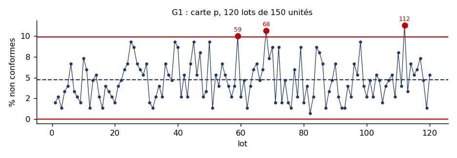

**a) Carte p.** $pˉ$ = 851 / 18 000 = 4,73 % ; LCS = 9,93 % ; LCI = 0. Lots hors limites : 59, 68, 112 (15, 16 et 17 non conformes, soit 10,0 % ; 10,7 % ; 11,3 %). Procédé hors contrôle sur ces trois lots : chercher ce qui s'est passé ces jours-là.

**b) Carte np.** LC = 7,09 ; LCS = 14,89 ; LCI = 0. Mêmes lots : la taille est constante (150), la carte np est la carte p multipliée par 150.

**c) Pourquoi LCI = 0 ?** $npˉ−3npˉ(1−pˉ)=7,09−7,80<0$ : une limite négative n'a pas de sens pour un nombre de pièces, on la remplace par 0.

## G2 · tableau de révision [Livret p. 16, fiche G2]

| Carte | Données | LC | LCS | LCI |
| --- | --- | --- | --- | --- |
| p | n = 100 ; p̄ = 0,05 | 0,05 | $0,05+31000,05×0,95=0,115$ | 0 |
| np | n = 150 ; p̄ = 0,07 | 10,5 | $10,5+310,5×0,93=19,87$ | 1,13 |
| c | c̄ = 4 | 4 | $4+34=10$ | 0 |
| X̄ (3 σ) | n = 4 ; X̿ = 15 ; R̄ = 6 | 15 | $15+0,729×6=19,37$ | 10,63 |
| XmR | X̄ = 35 ; m̄R = 5,5 | 35 | $35+2,66×5,5=49,63$ | 20,37 |

## Fiche F · exemple d'affiche attendue pour les butées [Livret p. 17, fiche F]

[output not shown]